# Model Selection

Kai Wombacher

3/30/2018

```r
library(ggplot2)
library(corrplot)
library(leaps)
library(gridExtra)
library(glmnet)
```

## Cleaning the Data

Let’s begin by reading the census data

```r
census_df_full = read.csv("nyc_census.csv") # read in file
set.seed(1) # reproducibility
dim(census_df_full)
```

```
## [1] 2167   36
```

Our data contains 2167 entries and 36 variables (or features)

```r
names(census_df_full)
```

```
##  [1] "CensusTract"     "County"          "Borough"
##  [4] "TotalPop"        "Men"             "Women"
##  [7] "Hispanic"        "White"           "Black"
## [10] "Native"          "Asian"           "Citizen"
## [13] "Income"          "IncomeErr"       "IncomePerCap"
## [16] "IncomePerCapErr" "Poverty"         "ChildPoverty"
## [19] "Professional"    "Service"         "Office"
## [22] "Construction"    "Production"      "Drive"
## [25] "Carpool"         "Transit"         "Walk"
## [28] "OtherTransp"     "WorkAtHome"      "MeanCommute"
## [31] "Employed"        "PrivateWork"     "PublicWork"
## [34] "SelfEmployed"    "FamilyWork"      "Unemployment"
```

Remove columns that does not pertain to predicting median household income

```r
census_df <- census_df_full[,-which(names(census_df_full) %in% c("Borough",
                                                                 "IncomeErr",
                                                                 "IncomePerCap",
                                                                 "IncomePerCapErr"))]
summary(census_df)
```

```
##   CensusTract             County       TotalPop          Men
##  Min.   :3.601e+10   Bronx   :339   Min.   :    0   Min.   :    0
##  1st Qu.:3.605e+10   Kings   :761   1st Qu.: 2360   1st Qu.: 1113
##  Median :3.605e+10   New York:288   Median : 3550   Median : 1699
##  Mean   :3.605e+10   Queens  :669   Mean   : 3889   Mean   : 1853
##  3rd Qu.:3.608e+10   Richmond:110   3rd Qu.: 4958   3rd Qu.: 2360
##  Max.   :3.609e+10                  Max.   :28926   Max.   :13460
##
##      Women          Hispanic          White            Black
##  Min.   :    0   Min.   :  0.00   Min.   :  0.00   Min.   :  0.00
##  1st Qu.: 1224   1st Qu.:  9.00   1st Qu.:  4.10   1st Qu.:  1.50
##  Median : 1848   Median : 18.40   Median : 22.95   Median :  7.80
##  Mean   : 2036   Mean   : 26.62   Mean   : 33.06   Mean   : 23.95
##  3rd Qu.: 2572   3rd Qu.: 39.90   3rd Qu.: 60.10   3rd Qu.: 39.08
##  Max.   :15466   Max.   :100.00   Max.   :100.00   Max.   :100.00
##                  NA's   :39       NA's   :39       NA's   :39
##      Native            Asian          Citizen          Income
##  Min.   : 0.0000   Min.   : 0.00   Min.   :    0   Min.   :  9829
##  1st Qu.: 0.0000   1st Qu.: 2.10   1st Qu.: 1446   1st Qu.: 39073
##  Median : 0.0000   Median : 6.70   Median : 2140   Median : 54505
##  Mean   : 0.1986   Mean   :13.44   Mean   : 2436   Mean   : 59101
##  3rd Qu.: 0.0000   3rd Qu.:18.93   3rd Qu.: 2976   3rd Qu.: 73272
##  Max.   :11.3000   Max.   :89.80   Max.   :22905   Max.   :244375
##  NA's   :39        NA's   :39                      NA's   :66
##     Poverty        ChildPoverty    Professional       Service
##  Min.   :  0.00   Min.   : 0.00   Min.   :  0.00   Min.   : 0.00
##  1st Qu.:  9.20   1st Qu.: 8.30   1st Qu.: 23.00   1st Qu.:15.70
##  Median : 16.70   Median :21.10   Median : 33.60   Median :24.55
##  Mean   : 19.57   Mean   :24.48   Mean   : 36.55   Mean   :24.23
##  3rd Qu.: 26.70   3rd Qu.:37.55   3rd Qu.: 45.80   3rd Qu.:32.12
##  Max.   :100.00   Max.   :95.70   Max.   :100.00   Max.   :59.80
##  NA's   :42       NA's   :60      NA's   :43       NA's   :43
##      Office        Construction      Production          Drive
##  Min.   :  0.00   Min.   : 0.000   Min.   :  0.000   Min.   :  0.00
##  1st Qu.: 19.30   1st Qu.: 3.300   1st Qu.:  5.500   1st Qu.: 10.90
##  Median : 23.10   Median : 6.100   Median :  8.950   Median : 20.75
##  Mean   : 23.43   Mean   : 6.634   Mean   :  9.157   Mean   : 24.88
##  3rd Qu.: 26.80   3rd Qu.: 9.200   3rd Qu.: 12.600   3rd Qu.: 36.33
##  Max.   :100.00   Max.   :43.200   Max.   :100.000   Max.   :100.00
##  NA's   :43       NA's   :43       NA's   :43        NA's   :43
```

[output cut: 9 more lines]

```
##  Min.   :  0.000   Min.   :15.20   Min.   :    0   Min.   : 38.60
##  1st Qu.:  1.300   1st Qu.:37.20   1st Qu.: 1052   1st Qu.: 75.00
##  Median :  2.800   Median :41.40   Median : 1579   Median : 79.90
##  Mean   :  3.749   Mean   :40.83   Mean   : 1813   Mean   : 79.54
##  3rd Qu.:  5.100   3rd Qu.:45.38   3rd Qu.: 2274   3rd Qu.: 84.40
##  Max.   :100.000   Max.   :70.50   Max.   :12780   Max.   :100.00
##  NA's   :43        NA's   :61                      NA's   :43
##    PublicWork     SelfEmployed      FamilyWork      Unemployment
##  Min.   : 0.00   Min.   : 0.000   Min.   :0.0000   Min.   :  0.000
##  1st Qu.: 8.80   1st Qu.: 3.500   1st Qu.:0.0000   1st Qu.:  5.900
##  Median :13.30   Median : 5.600   Median :0.0000   Median :  8.800
##  Mean   :14.19   Mean   : 6.151   Mean   :0.1186   Mean   :  9.758
##  3rd Qu.:18.70   3rd Qu.: 8.200   3rd Qu.:0.0000   3rd Qu.: 12.600
##  Max.   :53.70   Max.   :61.400   Max.   :3.9000   Max.   :100.000
##  NA's   :43      NA's   :43       NA's   :43       NA's   :42
```

Our Data still contain missing values. We will remove the rows where values are missing.

```r
census_df_naomit <- na.omit(census_df)
dim(census_df_naomit)
```

```
## [1] 2095   32
```

We will also remove the column ‘County’ because, while it might be preditictive, it will not contribute any interesting explanatory value. Additionally, we will remove ‘White’ and ‘Men’ because those data are repetitive as there is a ‘Women’ column, as well as columns for ‘Asian’, ‘Black’, ‘Hispanic’, and ‘Native’.

```r
census_df_rd2 <- census_df_naomit[,-which(names(census_df_naomit) %in% c("County",
                                                                         "White",
                                                                         "Men"))]
dim(census_df_rd2)
```

```
## [1] 2095   29
```

## Exploratory Analysis

First, lets look at the correlations between our variables. (Census Track not considered for same reason as borough).

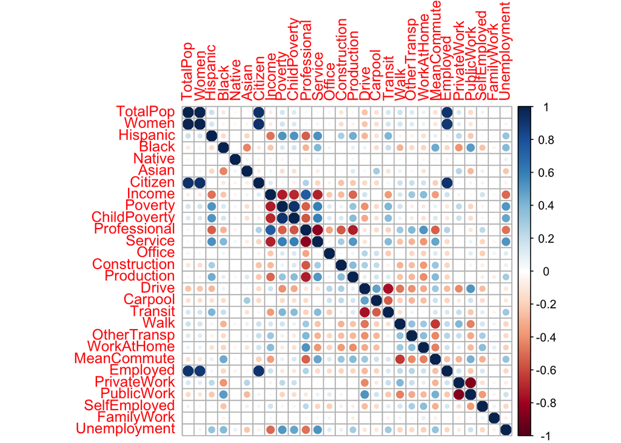

```r
corrMat = cor(census_df_rd2[,-1], use = "pairwise.complete.obs")
par(mfrow = c(1,1))
corrplot(corrMat, method = "circle")
```

TotalPopulation is highly corrlelated with Citizen (Number of Citizens). We will remove it as it is repetitive.

```r
census_df_rd2 <- census_df_rd2[,-which(names(census_df_rd2) %in% c("TotalPop"))]
census_df_pred <- census_df_rd2[,-which(names(census_df_rd2) %in% c("CensusTract"))]
dim(census_df_pred)
```

```
## [1] 2095   27
```

```r
names(census_df_pred)
```

```
##  [1] "Women"        "Hispanic"     "Black"        "Native"
##  [5] "Asian"        "Citizen"      "Income"       "Poverty"
##  [9] "ChildPoverty" "Professional" "Service"      "Office"
## [13] "Construction" "Production"   "Drive"        "Carpool"
## [17] "Transit"      "Walk"         "OtherTransp"  "WorkAtHome"
## [21] "MeanCommute"  "Employed"     "PrivateWork"  "PublicWork"
## [25] "SelfEmployed" "FamilyWork"   "Unemployment"
```

Now we will use Stepwise regressions to determine which features are the most predictive. To determine how many features to include in our model, we will look at the number of features and some model evaluation metrics: RSS, Cp, Adjusted R^2, and BIC.

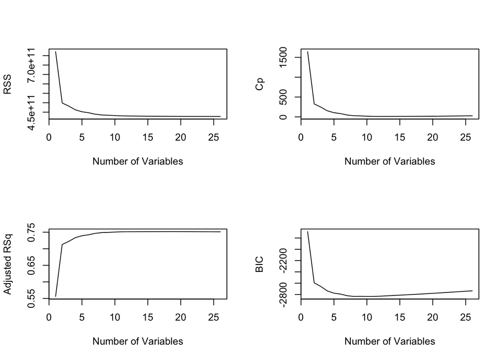

```r
set.seed(1) # reproducibility

regfit.full = regsubsets(Income~., data=census_df_pred, nvmax = 26)
reg.summary = summary(regfit.full)

par(mfrow = c(2,2))
plot(reg.summary$rss,xlab="Number of Variables",ylab="RSS",type="l")
plot(reg.summary$cp,xlab="Number of Variables",ylab="Cp",type='l')
plot(reg.summary$adjr2,xlab="Number of Variables",ylab="Adjusted RSq",type="l")
plot(reg.summary$bic,xlab="Number of Variables",ylab="BIC",type='l')
```

By examining the plots, we can see that after about 10 features are implemented, the RSS and Cp do not decrease much further. Additionally, the Adjusted R^2 does not increase much beyond 10 features and the BIC finds its minimum at about 10 variables implemented.

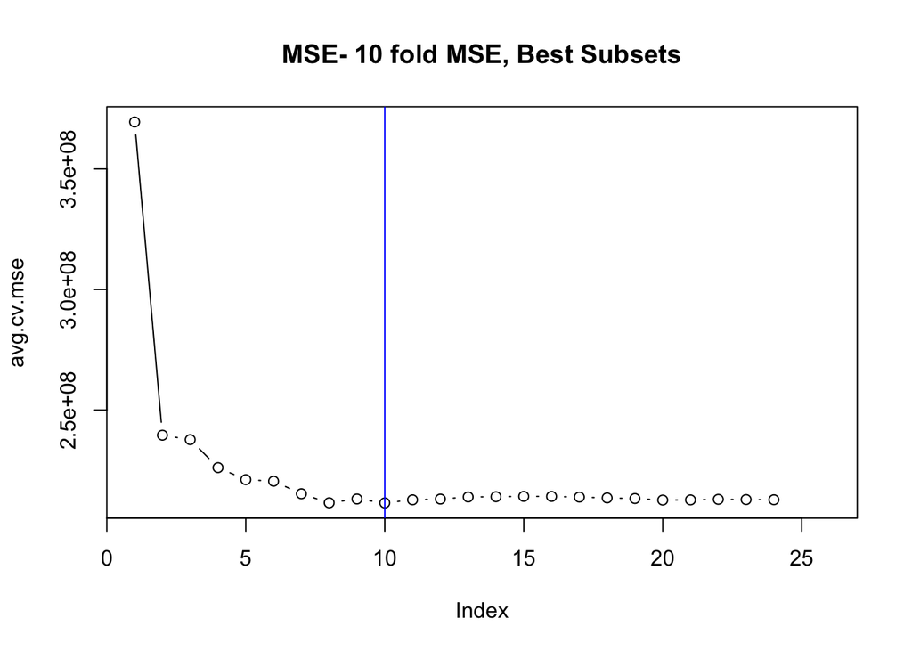

```r
set.seed(1000)
predict.regsubsets = function(object, newdata, id, ...){
  form = as.formula(object$call[[2]])
  mat = model.matrix(form, newdata)
  coefi = coef(object, id=id)
  xvars = names(coefi)
  mat[,xvars]%*%coefi
}

folds <- sample(1:10, nrow(census_df_pred), replace = TRUE)
cv.mse <- matrix(NA, nrow = 10, ncol = 26)
for(i in 1:10){
  best.sub <- regsubsets(Income~., data = census_df_pred[folds!=i,], nvmax = 26)
  for(j in 1:24){
    pred.s <- predict(best.sub, census_df_pred[folds ==i,], id = j)
    cv.mse[i,j] <- mean((census_df_pred$Income[folds ==i]- pred.s)^2)
  }
}
avg.cv.mse <- apply(cv.mse,2,mean)
plot(avg.cv.mse, type = "b", main = "MSE- 10 fold MSE, Best Subsets")
v = which.min(avg.cv.mse)
abline(v = which.min(avg.cv.mse), col = "blue")
```

We can now examine the most predictive variables.

```r
regfit.best = regsubsets(Income ~ ., data = census_df_pred, nvmax = 26)
coef(regfit.best,10)
```

```
##  (Intercept)        Asian      Citizen      Poverty Professional
## 42224.976679   -73.984665    -4.449046  -983.646845   662.388392
##        Drive         Walk  OtherTransp   WorkAtHome     Employed
##   333.649256   275.940011  1220.210411   957.029903     5.350176
##   PublicWork
##  -203.078227
```

## Evaluating Models

We will start by creating a base model - that is a model with all variables included.

```r
model.base = lm(Income ~ ., data = census_df_pred)
summary(model.base)
```

```
##
## Call:
## lm(formula = Income ~ ., data = census_df_pred)
##
## Residuals:
##    Min     1Q Median     3Q    Max
## -44172  -8780   -830   7364 113779
##
## Coefficients:
##                Estimate Std. Error t value Pr(>|t|)
## (Intercept)  -2.544e+05  9.415e+05  -0.270  0.78703
## Women        -8.269e-01  1.080e+00  -0.766  0.44380
## Hispanic      5.123e+01  2.459e+01   2.083  0.03736 *
## Black         5.133e+01  1.904e+01   2.696  0.00708 **
## Native        4.934e+01  4.716e+02   0.105  0.91669
## Asian        -1.920e+01  2.718e+01  -0.707  0.47994
## Citizen      -3.823e+00  8.958e-01  -4.268 2.06e-05 ***
## Poverty      -1.051e+03  7.498e+01 -14.023  < 2e-16 ***
## ChildPoverty  4.323e+01  4.305e+01   1.004  0.31538
## Professional -2.195e+03  4.958e+03  -0.443  0.65800
## Service      -2.927e+03  4.958e+03  -0.590  0.55510
## Office       -2.932e+03  4.958e+03  -0.591  0.55425
## Construction -2.812e+03  4.963e+03  -0.567  0.57110
## Production   -2.907e+03  4.956e+03  -0.587  0.55759
## Drive         7.685e+03  4.615e+03   1.665  0.09600 .
## Carpool       7.282e+03  4.617e+03   1.577  0.11489
## Transit       7.322e+03  4.614e+03   1.587  0.11274
## Walk          7.611e+03  4.614e+03   1.650  0.09918 .
## OtherTransp   8.509e+03  4.618e+03   1.843  0.06553 .
## WorkAtHome    8.312e+03  4.618e+03   1.800  0.07202 .
## MeanCommute  -6.735e+01  7.324e+01  -0.920  0.35791
## Employed      5.343e+00  1.001e+00   5.336 1.06e-07 ***
## PrivateWork  -1.464e+03  6.257e+03  -0.234  0.81497
## PublicWork   -1.739e+03  6.257e+03  -0.278  0.78107
## SelfEmployed -1.604e+03  6.258e+03  -0.256  0.79768
## FamilyWork   -1.775e+01  6.297e+03  -0.003  0.99775
## Unemployment  1.107e+02  8.307e+01   1.333  0.18267
## ---
## Signif. codes:  0 '***' 0.001 '**' 0.01 '*' 0.05 '.' 0.1 ' ' 1
##
## Residual standard error: 14370 on 2068 degrees of freedom
## Multiple R-squared:  0.7543, Adjusted R-squared:  0.7512
## F-statistic: 244.2 on 26 and 2068 DF,  p-value: < 2.2e-16
```

Next, we will create a model with the features we found most predictive: Asian, Citizen, Poverty, Professional, Drive, Walk, OtherTransp WorkAtHome, Employed, and Public Work.

```r
model.1 = lm(Income
               ~Asian
               +Citizen
               +Poverty
               +Walk
               +Drive
               +Professional
               +PublicWork
               +Employed
               +OtherTransp
               +WorkAtHome
               , data=census_df_pred)
summary(model.1)
```

```
##
## Call:
## lm(formula = Income ~ Asian + Citizen + Poverty + Walk + Drive +
##     Professional + PublicWork + Employed + OtherTransp + WorkAtHome,
##     data = census_df_pred)
##
## Residuals:
##    Min     1Q Median     3Q    Max
## -41430  -8656   -909   7626 117038
##
## Coefficients:
##                Estimate Std. Error t value Pr(>|t|)
## (Intercept)  42224.9767  2403.1827  17.570  < 2e-16 ***
## Asian          -73.9847    21.2780  -3.477 0.000517 ***
## Citizen         -4.4490     0.6364  -6.991 3.67e-12 ***
## Poverty       -983.6468    40.0595 -24.555  < 2e-16 ***
## Walk           275.9400    44.2975   6.229 5.65e-10 ***
## Drive          333.6493    28.8678  11.558  < 2e-16 ***
## Professional   662.3884    29.4342  22.504  < 2e-16 ***
## PublicWork    -203.0782    62.3687  -3.256 0.001148 **
## Employed         5.3502     0.8542   6.263 4.57e-10 ***
## OtherTransp   1220.2104   148.8123   8.200 4.16e-16 ***
## WorkAtHome     957.0299   126.7236   7.552 6.37e-14 ***
## ---
## Signif. codes:  0 '***' 0.001 '**' 0.01 '*' 0.05 '.' 0.1 ' ' 1
##
## Residual standard error: 14390 on 2084 degrees of freedom
## Multiple R-squared:  0.7517, Adjusted R-squared:  0.7505
## F-statistic: 630.8 on 10 and 2084 DF,  p-value: < 2.2e-16
```

Both of these models have about the same Adjusted R^2 value - 0.75. However, many of the variables in the base model have large p-values while all of the variables in model.1 have p-values < 0.05.

We can also evaluate these models using cross-validation to see how each model performs on a test set after being training set.

```r
set.seed(1)
k = 10
folds = cut(seq(1,nrow(census_df_pred)),breaks=10,labels=FALSE)
folds = folds[sample(length(folds))]
cv.errors = matrix(NA,k,2)

for (j in 1:k){
  lm.fit.base = lm(Income ~ .,data=census_df_pred[folds!=j,])
  lm.fit.1 = lm(Income ~ Asian+Citizen+Poverty+Walk+Drive+Professional+PublicWork+Employed+OtherTransp+WorkAtHome,
                data=census_df_pred[folds!=j,])
  pred.base = predict(lm.fit.base,census_df_pred[folds==j,])
  pred.1 = predict(lm.fit.1,census_df_pred[folds==j,])
  cv.errors[j,1] = mean((census_df_pred$Income[folds==j]-pred.base)^2)
  cv.errors[j,2] = mean((census_df_pred$Income[folds==j]-pred.1)^2)
}
print(cv.errors)
```

```
##            [,1]      [,2]
##  [1,] 248527485 251724006
##  [2,] 220929894 222022723
##  [3,] 159353898 163351237
##  [4,] 259973716 256143269
##  [5,] 197994327 197747531
##  [6,] 305425172 298835908
##  [7,] 187016972 181886324
##  [8,] 156399973 152029644
##  [9,] 191597209 187772276
## [10,] 190092203 186840198
```

```r
mean.cv.errors = apply(cv.errors,2,mean)
print(mean.cv.errors)
```

```
## [1] 211731085 209835312
```

As expected, model.1 has a smaller error value because it did not overfit the training set as much. Perhaps, we can improve upon this model. Looking at the plots of each variable, it seems some might have data that are skewed.

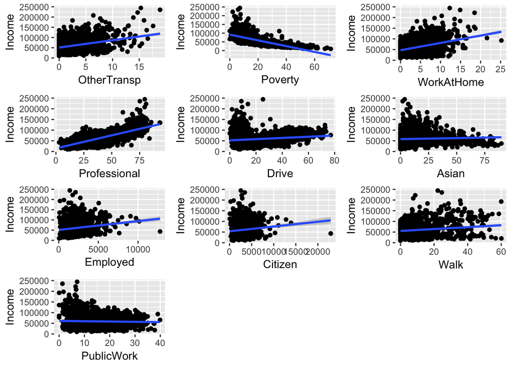

```r
p1 <- ggplot(census_df_pred, aes(OtherTransp,Income)) + geom_point() + geom_smooth(method ="lm")
p2 <- ggplot(census_df_pred, aes(Poverty,Income)) + geom_point() + geom_smooth(method ="lm")
p3 <- ggplot(census_df_pred, aes(WorkAtHome,Income)) + geom_point() + geom_smooth(method ="lm")
p4 <- ggplot(census_df_pred, aes(Professional,Income)) + geom_point() + geom_smooth(method ="lm")
p5 <- ggplot(census_df_pred, aes(Drive,Income)) + geom_point() + geom_smooth(method ="lm")
p6 <- ggplot(census_df_pred, aes(Asian,Income)) + geom_point() + geom_smooth(method ="lm")
p7 <- ggplot(census_df_pred, aes(Employed,Income)) + geom_point() + geom_smooth(method ="lm")
p8 <- ggplot(census_df_pred, aes(Citizen,Income)) + geom_point() + geom_smooth(method ="lm")
p9 <- ggplot(census_df_pred, aes(Walk,Income)) + geom_point() + geom_smooth(method ="lm")
p10 <- ggplot(census_df_pred, aes(PublicWork,Income)) + geom_point() + geom_smooth(method ="lm")


grid.arrange(p1,p2,p3,p4,p5,p6,p7,p8,p9,p10)
```

We can look at the kernel density for each variable to get a better idea of the data’s distribution.

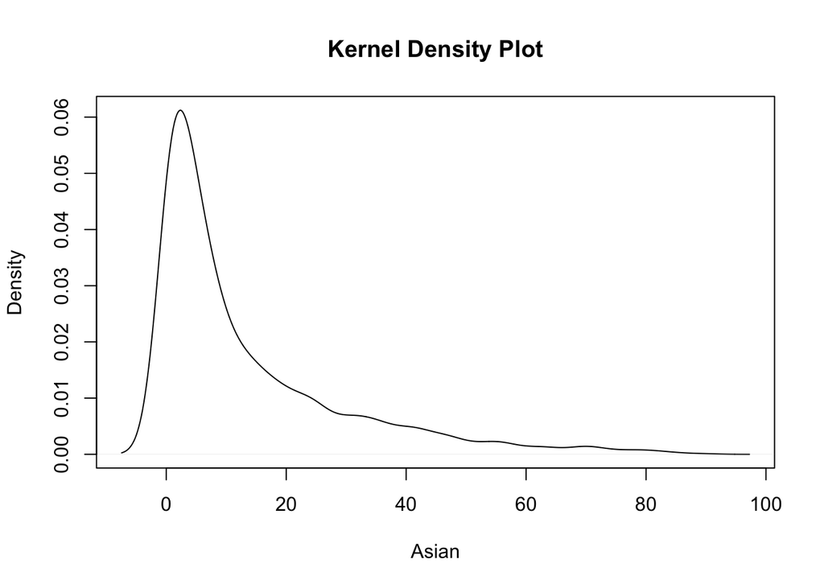

```r
plot(density(census_df_pred$Asian), xlab = 'Asian', ylab = 'Density', main = 'Kernel Density Plot')
```

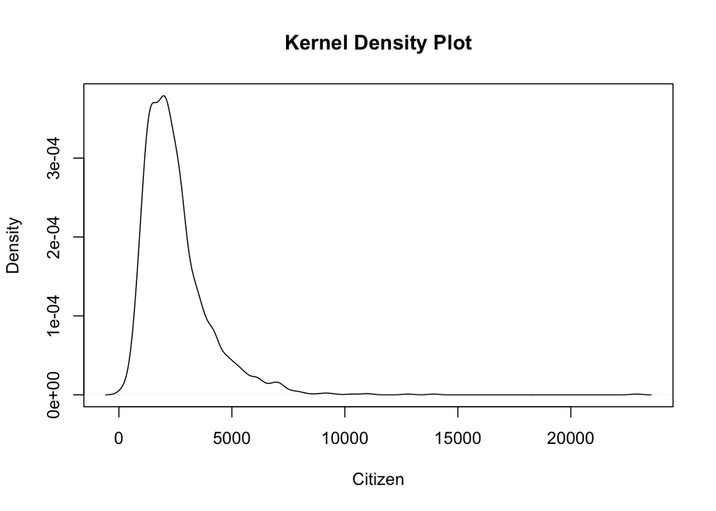

```r
plot(density(census_df_pred$Citizen), xlab = 'Citizen', ylab = 'Density', main = 'Kernel Density Plot')
```

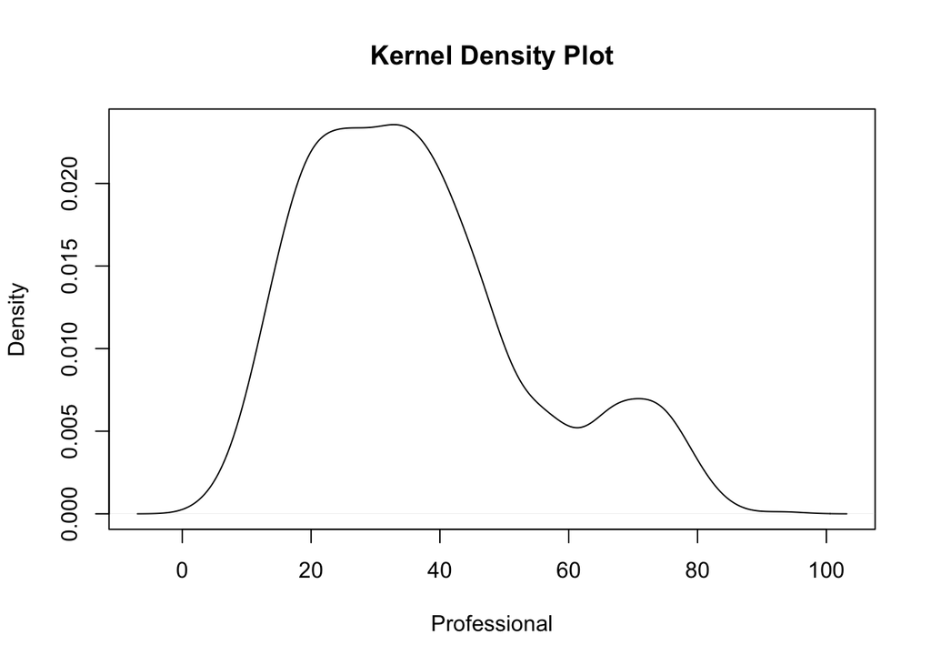

```r
plot(density(census_df_pred$Professional), xlab = 'Professional', ylab = 'Density', main = 'Kernel Density Plot')
```

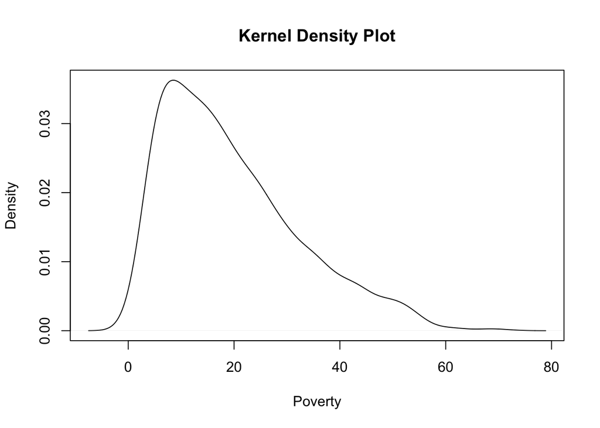

```r
plot(density(census_df_pred$Poverty), xlab = 'Poverty', ylab = 'Density', main = 'Kernel Density Plot')
```

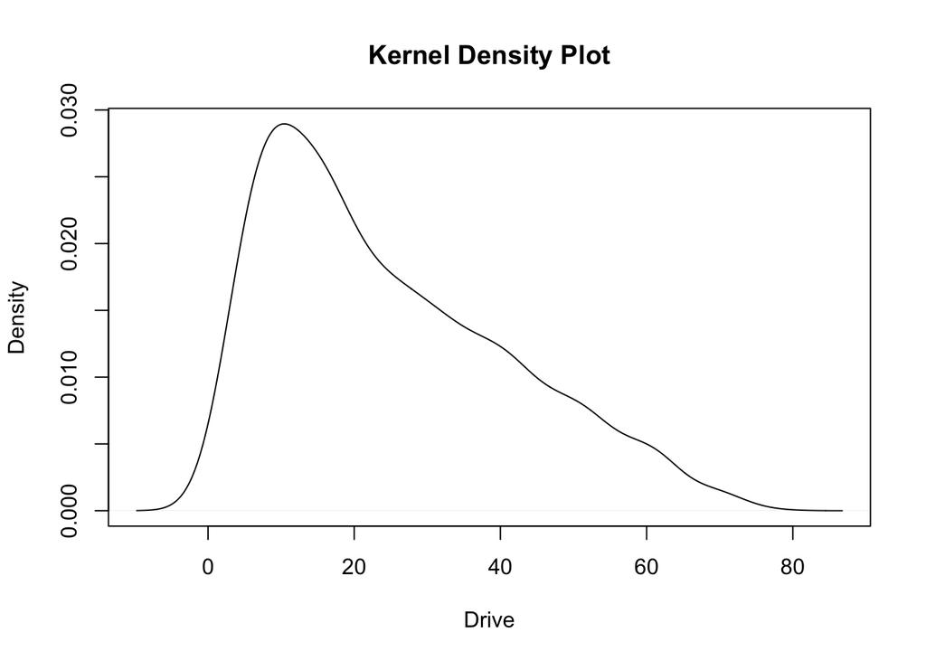

```r
plot(density(census_df_pred$Drive), xlab = 'Drive', ylab = 'Density', main = 'Kernel Density Plot')
```

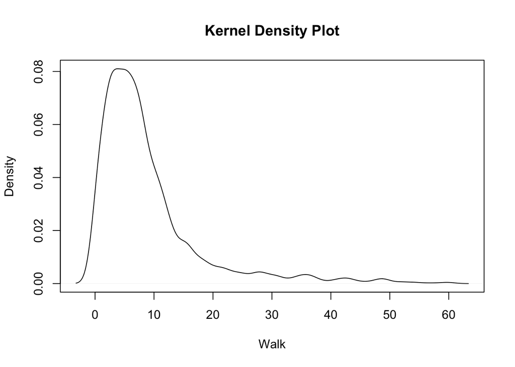

```r
plot(density(census_df_pred$Walk), xlab = 'Walk', ylab = 'Density', main = 'Kernel Density Plot')
```

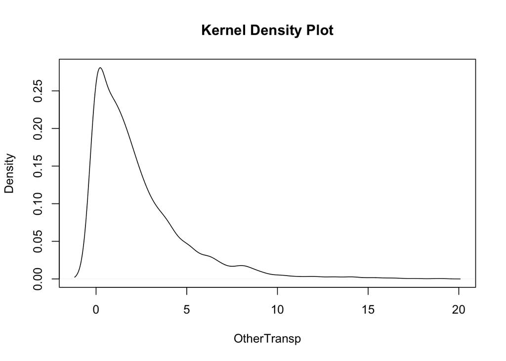

```r
plot(density(census_df_pred$OtherTransp), xlab = 'OtherTransp', ylab = 'Density', main = 'Kernel Density Plot')
```

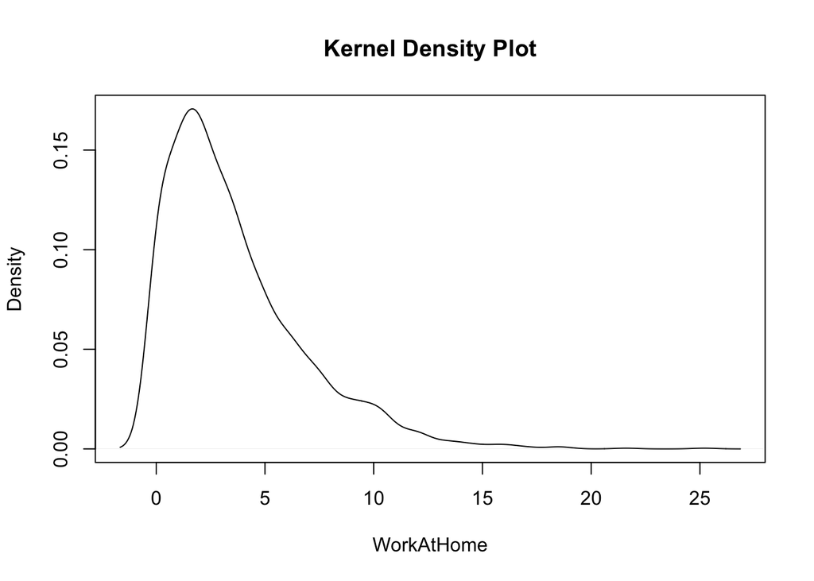

```r
plot(density(census_df_pred$WorkAtHome), xlab = 'WorkAtHome', ylab = 'Density', main = 'Kernel Density Plot')
```

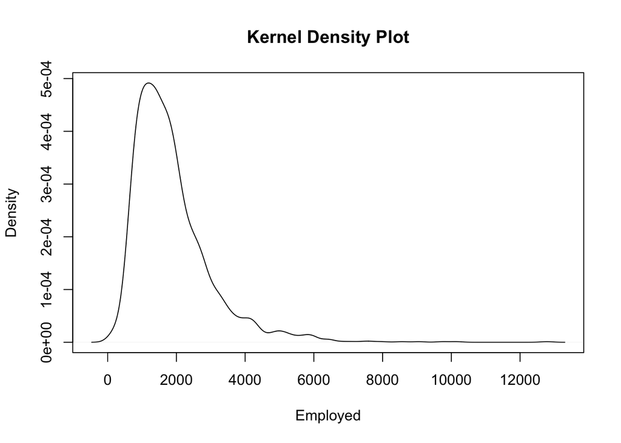

```r
plot(density(census_df_pred$Employed), xlab = 'Employed', ylab = 'Density', main = 'Kernel Density Plot')
```

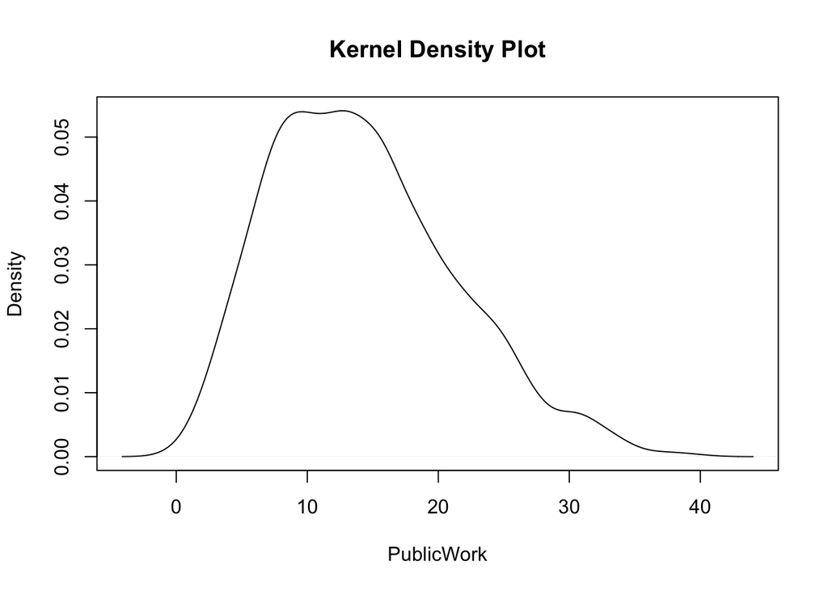

```r
plot(density(census_df_pred$PublicWork), xlab = 'PublicWork', ylab = 'Density', main = 'Kernel Density Plot')
```

After review the distributions of the variables, it was clear that Poverty and PublicWork appear to be exponentially distributed. Therefore, we will log-transform them to make their distribution more linear. Note: When we log-transform, we will add constant to the data to avoid taking the log of 0.

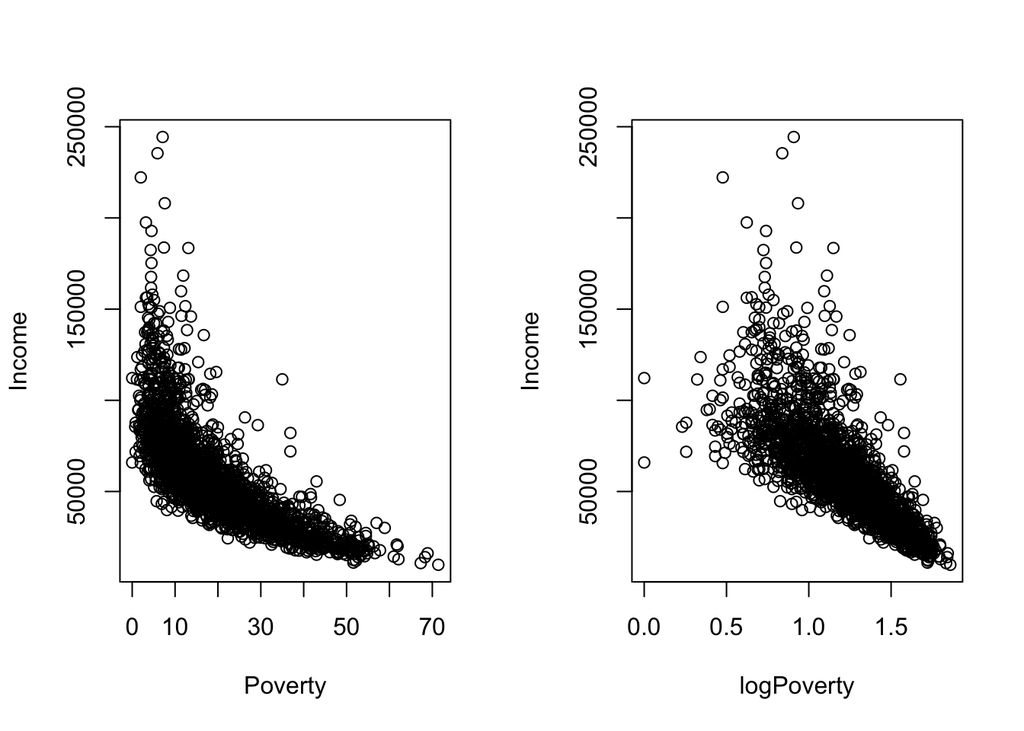

```r
constant = 1
census_df_pred$logPoverty = log10(census_df_pred$Poverty+constant)
census_df_pred$logPublicWork = log10(census_df_pred$PublicWork+constant)

par(mfrow = c(1,2))
plot(census_df_pred$Poverty, census_df_pred$Income, xlab = 'Poverty', ylab = 'Income')
plot(census_df_pred$logPoverty, census_df_pred$Income, xlab = 'logPoverty', ylab = 'Income')
```

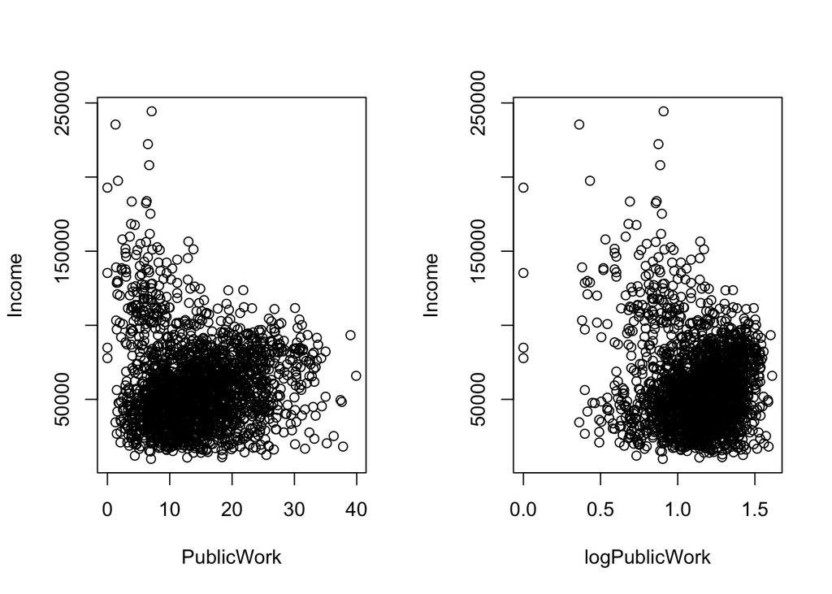

```r
plot(census_df_pred$PublicWork, census_df_pred$Income, xlab = 'PublicWork', ylab = 'Income')
plot(census_df_pred$logPublicWork, census_df_pred$Income, xlab = 'logPublicWork', ylab = 'Income')
```

Now we can compare our previously optimized model with 10 variables: Asian, Citizen, Poverty, Walk, Drive, Professional, PublicWork, Employed, OtherTransp, WorkAtHome, to the optimized model with logPoverty a logPublicWork as log-transformed variables. We will evaluate the models using the MSE of their test set.

```r
set.seed(1)
k = 10
folds = cut(seq(1,nrow(census_df_pred)),breaks=10,labels=FALSE)
folds = folds[sample(length(folds))]
cv.errors = matrix(NA,k,2)

for (j in 1:k){
  lm.fit.1 = lm(Income ~ Asian+Citizen+Poverty+Walk+Drive+Professional+PublicWork+Employed+OtherTransp+WorkAtHome,
                data=census_df_pred[folds!=j,])
  lm.fit.2 = lm(Income ~ Asian+Citizen+logPoverty+Walk+Drive+Professional+logPublicWork+Employed+OtherTransp+WorkAtHome,
                data=census_df_pred[folds!=j,])
  pred.1 = predict(lm.fit.1,census_df_pred[folds==j,])
  pred.2 = predict(lm.fit.2,census_df_pred[folds==j,])
  cv.errors[j,1] = mean((census_df_pred$Income[folds==j]-pred.1)^2)
  cv.errors[j,2] = mean((census_df_pred$Income[folds==j]-pred.2)^2)
}
print(cv.errors)
```

```
##            [,1]      [,2]
##  [1,] 251724006 231694979
##  [2,] 222022723 196713851
##  [3,] 163351237 138788165
##  [4,] 256143269 240578968
##  [5,] 197747531 182761393
##  [6,] 298835908 257579308
##  [7,] 181886324 152345261
##  [8,] 152029644 164490331
##  [9,] 187772276 160251125
## [10,] 186840198 178157669
```

```r
mean.cv.errors = apply(cv.errors,2,mean)
print(mean.cv.errors)
```

```
## [1] 209835312 190336105
```

As we can see by examing the cross-validated MSE of both models, the model with Poverty and PublicWork as log-transformed variables *improves* the model.

We can now use our optimized subset variables and use Ridge/Lasso Regression instead of normal linear regression. We will use cross-validation to select the optimal lambda values and to calculate the MSE on a test set.

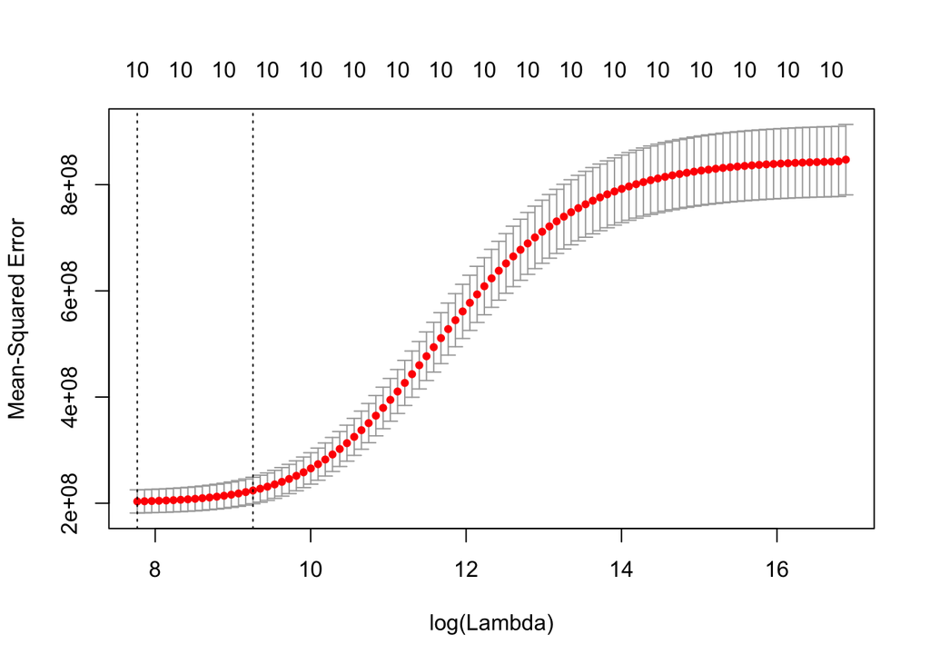

```r
x <- model.matrix(Income~Asian+Citizen+logPoverty+Walk+Drive+Professional+logPublicWork+Employed+OtherTransp+WorkAtHome, census_df_pred)
x <- x[,-c(1)] # remove the intercept term
y <- census_df_pred$Income

set.seed(1)
train=sample(1:nrow(x), nrow(x)/2)
test=(-train)
y.test=y[test]

grid=10^seq(10,-2,length=100)    #Grid of lambda values

ridge.mod=glmnet(x[train,],y[train],alpha=0,lambda=grid, thresh=1e-12)

set.seed(100)
cv.out=cv.glmnet(x[train,],y[train],alpha=0,nfolds=10)
plot(cv.out)
```

```r
bestlam=cv.out$lambda.min   #Lambda with minimum MSE
ridge.pred=predict(ridge.mod,s=bestlam,newx=x[test,])
mean((ridge.pred-y.test)^2)  #Test MSE associated with smallest lambda
```

```
## [1] 183614607
```

```r
out=glmnet(x,y,alpha=0)
predict(out,type="coefficients",s=bestlam)  #Now get ridge coefficients for model with best lambda
```

```
## 11 x 1 sparse Matrix of class "dgCMatrix"
##                           1
## (Intercept)    95104.391305
## Asian             -8.281436
## Citizen           -2.146842
## logPoverty    -45148.025806
## Walk             105.523892
## Drive            236.543204
## Professional     594.285321
## logPublicWork -12653.873652
## Employed           2.604142
## OtherTransp     1136.245901
## WorkAtHome       826.718951
```

The Ridge Regression does in fact have a lower MSE! Let’s test Lasso.

```r
dim(x)
```

```
## [1] 2095   10
```

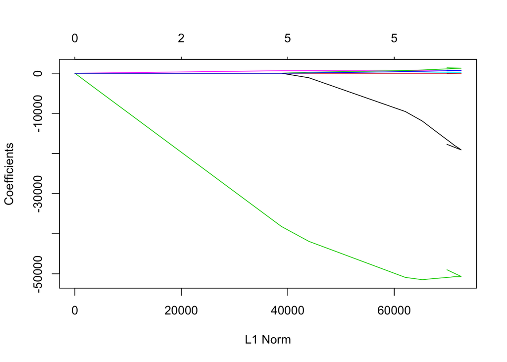

```r
lasso.mod=glmnet(x[train,],y[train],alpha=1,lambda=grid)
plot(lasso.mod)
```

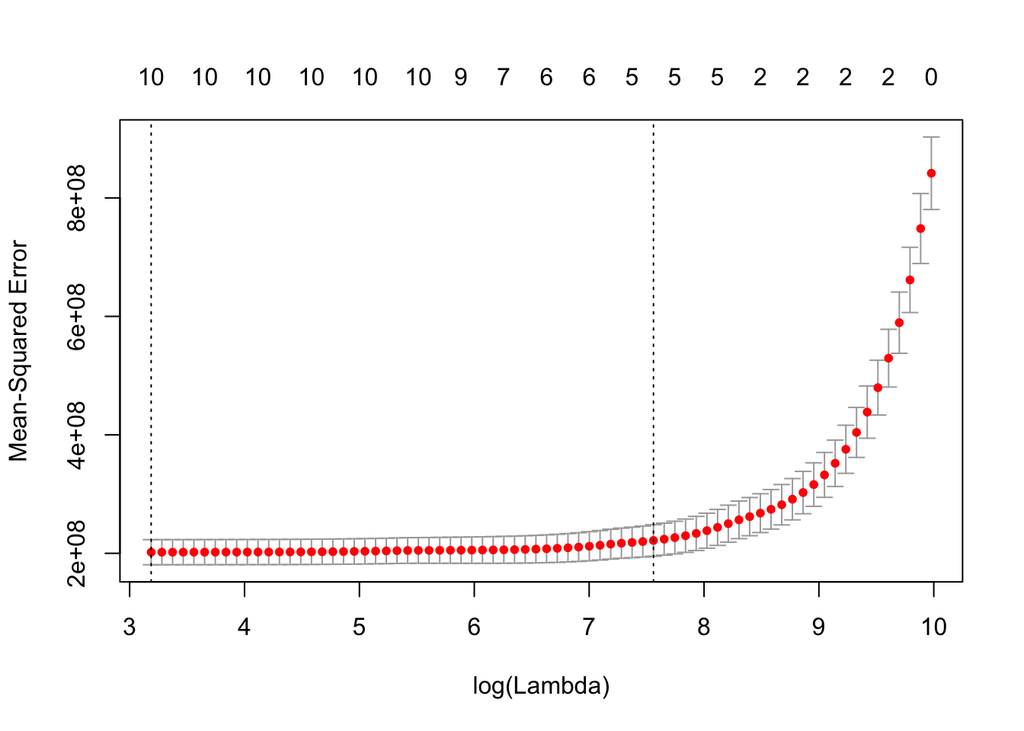

```r
set.seed(1)
cv.out=cv.glmnet(x[train,],y[train],alpha=1)
plot(cv.out)
```

```r
bestlam=cv.out$lambda.min
lasso.pred=predict(lasso.mod,s=bestlam,newx=x[test,])
mean((lasso.pred-y.test)^2)
```

```
## [1] 183231184
```

```r
out=glmnet(x,y,alpha=1,lambda=grid)
lasso.coef=predict(out,type="coefficients",s=bestlam)
lasso.coef
```

```
## 11 x 1 sparse Matrix of class "dgCMatrix"
##                           1
## (Intercept)    95282.182751
## Asian            -33.349449
## Citizen           -4.395160
## logPoverty    -46647.635918
## Walk             122.946140
## Drive            267.424960
## Professional     636.772997
## logPublicWork -12550.565488
## Employed           5.430311
## OtherTransp     1105.262520
## WorkAtHome       778.278605
```

As we can see, using Ridge and Lasso Regression (with optimal lambda values) results in a lower test MSE. The lasso regression does perform slightly better, however, both models return similar coefficient values - both models have logPoverty and logPublicWork as large, negative coefficients, and OtherTransp, WorkAtHome, and Professional as large, positive coefficient values.